# Team Work file

Aaron Jencks, Eli Musgrove

3/19/2020

## Part 1: Cleaning

1. The player names and opponent names are factors

```r
# Create new dataframes to be cleand
defClean = data.frame(defense)
offClean = data.frame(offense)
bioClean = data.frame(bio)

# Factorize player names
total_names_list = unique(c(defense$Name, offense$Name, bio$Name))
defClean$Name = factor(defense$Name, levels=total_names_list)
offClean$Name = factor(offense$Name, levels=total_names_list)
bioClean$Name = factor(bio$Name, levels=total_names_list)

# Factorize opponent names
total_opponent_names_list = unique(c(defense$Opponent_Opponent, offense$Opponent_Opponent))
defClean$Opponent_Opponent = factor(defense$Opponent_Opponent, levels=total_opponent_names_list)
offClean$Opponent_Opponent = factor(offense$Opponent_Opponent, levels=total_opponent_names_list)
```

2. All offensive and defensive statistics are numerical. The Weight column in biography is also numeric.

```r
defClean = defClean %>% mutate_at(colnames(defClean)[3:11], as.numeric)
offClean = offClean %>% mutate_at(colnames(offClean)[3:12], as.numeric)
bioClean$Weight = as.numeric(bioClean$Weight)
```

3. Change the Height column in biography into numeric.

```r
bioClean = bioClean %>% mutate(height_feet = (function(element) {

  # You'll need the stringr package for these methods,
  # they are used to splice the feet and inches parts of the Height
  index = (element %>% str_locate("-"))[,1]
  result = as.numeric(element %>% str_sub(rep(1, length(index)), index - 1))
  return(result)

})(Height),

Height = (function(elements) {

  # Converts feet into inches, and then adds the inches
  index = (elements %>% str_locate("-"))[,1]
    feet = as.numeric(elements %>% str_sub(1, index - 1)) * 12
    inches = as.numeric(elements %>% str_sub(index + 1, rep(length(elements), length(elements))))
    result = feet + inches
    return(result)

})(Height))
```

```r
# Final clean dataframes
str(defClean)
```

```
## 'data.frame':    502 obs. of  11 variables:
##  $ Name             : Factor w/ 121 levels "White, Lawrence",..: 1 1 1 1 1 1 1 1 1 1 ...
##  $ Opponent_Opponent: Factor w/ 13 levels "UNI","Iowa","ULM",..: 1 2 3 4 5 6 7 8 9 10 ...
##  $ Tackles_Solo     : num  4 4 3 4 3 1 7 3 6 5 ...
##  $ Tackles_ASST     : num  4 7 5 2 2 1 1 2 1 5 ...
##  $ Tackles_TFL      : num  0 0 0 0 1 0 0 0 1 1 ...
##  $ Tackles_Sack     : num  0 0 0 0 0 0 0 0 0 1 ...
##  $ Turnover_FF      : num  0 0 0 0 0 0 0 0 0 0 ...
##  $ Turnover_FR      : num  0 0 0 0 0 0 0 0 0 0 ...
##  $ Turnover_INT     : num  0 0 1 0 0 0 0 0 1 0 ...
##  $ Pass_QBH         : num  1 0 0 0 0 0 0 0 1 0 ...
##  $ Pass_PB          : num  1 2 0 0 0 1 0 0 0 0 ...
```

```r
str(offClean)
```

```
## 'data.frame':    195 obs. of  12 variables:
##  $ Name             : Factor w/ 121 levels "White, Lawrence",..: 19 19 19 19 19 19 19 19 19 19 ...
##  $ Opponent_Opponent: Factor w/ 13 levels "UNI","Iowa","ULM",..: 1 2 3 4 5 6 7 8 9 10 ...
##  $ Rushing_ATT      : num  0 0 1 0 0 0 0 0 0 0 ...
##  $ Rushing_YDS      : num  0 0 8 0 0 0 0 0 0 0 ...
##  $ Rushing_TD       : num  0 0 0 0 0 0 0 0 0 0 ...
##  $ Receiving_REC    : num  1 0 0 0 1 0 0 4 0 1 ...
##  $ Receiving_YDS    : num  21 0 0 0 32 0 0 39 0 7 ...
##  $ Receiving_TD     : num  0 0 0 0 0 0 0 0 0 0 ...
##  $ Passing_CMP.ATT  : num  NA NA NA NA NA NA NA NA NA NA ...
##  $ Passing_YDS      : num  NA NA NA NA NA NA NA NA NA NA ...
##  $ Passing_TD       : num  NA NA NA NA NA NA NA NA NA NA ...
##  $ Passing_INT      : num  NA NA NA NA NA NA NA NA NA NA ...
```

```r
str(bioClean)
```

```
## 'data.frame':    105 obs. of  8 variables:
##  $ Name       : Factor w/ 121 levels "White, Lawrence",..: 19 33 53 54 10 55 20 56 57 58 ...
##  $ Position   : chr  "Wide Receiver" "Tight End" "Wide Receiver" "Placekicker" ...
##  $ Height     : num  72 79 77 72 72 75 74 74 72 78 ...
##  $ Weight     : num  188 245 204 195 190 235 255 285 300 215 ...
##  $ Class      : chr  "Redshirt Senior" "Redshirt Senior" "Redshirt Freshman" "Redshirt Senior" ...
##  $ Hometown   : chr  "Cedar Rapids, Iowa" "Nixa, Mo." "Seffner, Fla." "Naperville, Ill." ...
##  $ Highschool : chr  "Washington" "Nixa" "Armwood" "Central" ...
##  $ height_feet: num  6 6 6 6 6 6 6 6 6 6 ...
```

## Part 2: Tidying

### Part 1

1. Reformat the defClean data frame into tidy format using `pivot_longer`. The type of statistic (Tackles_Solo, Tackles_ASST, etc) is added as a new key column named Statistic.

```r
defClean = defClean %>%
  pivot_longer(Tackles_Solo:Pass_PB, names_to='Statistic', values_to='Value')
```

2. Create a histogram for each defensive statistic. Use `facet_wrap` to draw all histograms in a single plot. What defensive skills are rare?

##### The defensive skills ‘Turnover_FF’, ‘Turnover_FR’, and ‘Turnover_INT’ are rare with most values close to 0. This is because turnovers are pretty rare in the course of a game while tackling would occur more often.

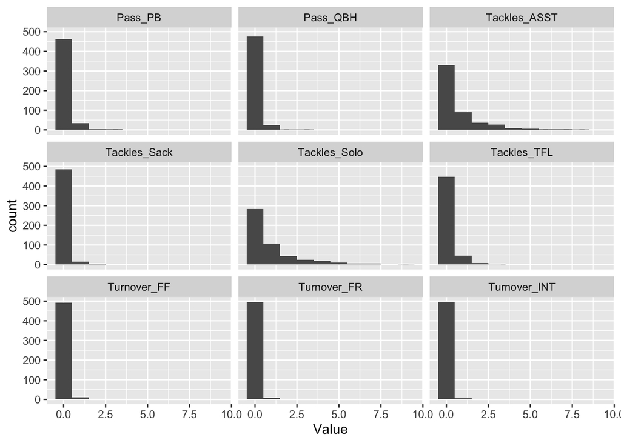

```r
ggplot(defClean, aes(x=Value)) + geom_histogram() + facet_wrap(~Statistic) + stat_bin(bins=10)
```

3. Did ISU have better defense against West Virginia or Kansas State? Answer this question by creating a scatterplot with x-axis being the number of solo tackles against West Virginia, and y-axis being that against Kansas State. A large number of solo tackles indicates a good defense.

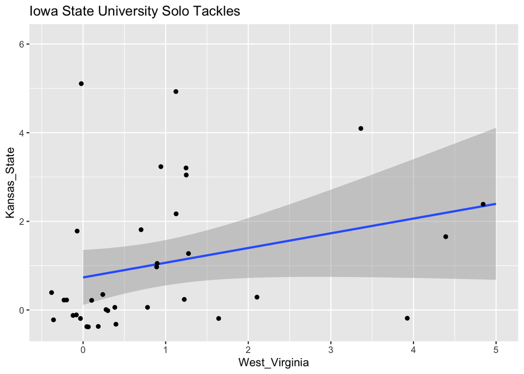

```r
# Prep dataframe
defComp = defClean %>% filter(Statistic == 'Tackles_Solo') %>% filter(Opponent_Opponent %in% c('West Virginia', 'Kansas State')) %>%       pivot_wider(names_from=Opponent_Opponent, values_from=Value)

colnames(defComp) = c('Name', 'Statistic', 'West_Virginia', 'Kansas_State')
ggplot(defComp, aes(x=West_Virginia, y=Kansas_State)) + geom_smooth(method='lm') + geom_point(position='jitter') + ggtitle('Iowa State University Solo Tackles')
```

### Part 2

1. Separate the Hometown column into two columns, namely the city and the state. Print the first few rows of these two columns.

```r
bioClean = bioClean %>% separate(Hometown, c('City', 'State'), sep=',', remove=FALSE)
head(bioClean['City'])
```

```
##            City
## 1  Cedar Rapids
## 2          Nixa
## 3       Seffner
## 4    Naperville
## 5 Grand Prairie
## 6    Clarksdale
```

```r
head(bioClean['State'])
```

```
##    State
## 1   Iowa
## 2    Mo.
## 3   Fla.
## 4   Ill.
## 5  Texas
## 6  Miss.
```

2. How many players are there from each state?

```r
fromStates = bioClean %>% group_by(State) %>% tally()
print(fromStates, n=Inf)
```

```
## # A tibble: 19 x 2
##    State            n
##    <chr>        <int>
##  1 " Ariz."         4
##  2 " Ark."          1
##  3 " Australia"     1
##  4 " Calif."        3
##  5 " Fla."         10
##  6 " Ga."           4
##  7 " Ill."          5
##  8 " Iowa"         35
##  9 " Kan."          3
## 10 " Mich."         4
## 11 " Minn."         4
## 12 " Miss."         1
## 13 " Mo."           6
## 14 " Ohio"          7
## 15 " Okla."         2
## 16 " Pa."           1
## 17 " S.D."          2
## 18 " Texas"         6
## 19 " Wis."          6
```

## Part 3: Joining data frames

1. Find where the offensive players come from by joining the offensive data and player biography data appropriately.

```r
# Use full_join, only because it wasn't specified to get rid of N/A values
hometowns = full_join(offClean, bioClean, by="Name") %>% select(Name, Hometown) %>% distinct()
head(hometowns)
```

```
##                  Name            Hometown
## 1       Akers, Landen  Cedar Rapids, Iowa
## 2      Soehner, Dylan Prairie Grove, Ark.
## 3        Allen, Chase           Nixa, Mo.
## 4      Wilson, Darren     Alpharetta, Ga.
## 5      Kolar, Charlie       Norman, Okla.
## 6 Pettway, La'Michael                <NA>
```

2. Is there a relationship between the weight of a player and the receiving yards (`Receiving_YDS`)?

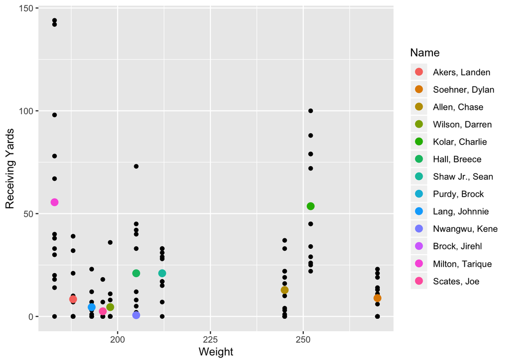

```r
# Use inner_join this time, because we aren't interested in N/A values
weight_yards = inner_join(bioClean, offClean, by="Name") %>%
           select(Name, Weight, Receiving_YDS) %>%
           group_by(Name) %>%
           mutate(mean_yds = mean(Receiving_YDS))

ggplot(distinct(weight_yards, Name, .keep_all=TRUE), aes(x=Weight, y=mean_yds, color=Name)) + ylab("Receiving Yards") +
    geom_point(data=weight_yards, aes(x=Weight, y=Receiving_YDS), show.legend=FALSE, inherit.aes=FALSE) +
    geom_point(size=3)
```

3. How does the performance of quarterback Brock Purdy relate to the performance for the ISU team?

##### As a quarterback, Brock’s performance should be compared to the other offensive players. One of the most important statistics for quarterbacks is the passing yards. Compared to the other players with non-null passing yards, Brock is far superior in comparision.

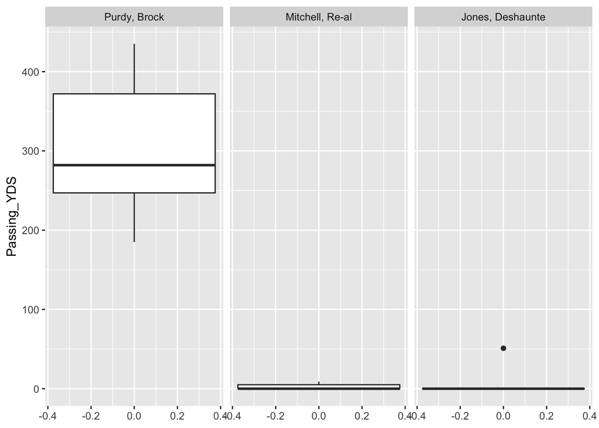

```r
# Join bio and offensive tables and select passing_yds
perf = full_join(bioClean, offClean, by='Name') %>% group_by(Name) %>% select(Name, Passing_YDS)
perf = na.omit(perf)

ggplot(perf, aes(y=Passing_YDS)) + geom_boxplot() + facet_wrap(~Name)
```

4. Explore more. You may in addition explore the 2018 data (see slides). Raise a question that can be answered only by looking at two or more data frames. Then answer that question.

##### Question: Among the offensive players, which state produced the most players? Which states produce the most defensive players?

##### The states Florida and Oklahoma are tied with 2 players from each state. Since offensive positions are very important, coaches are more likely to look outside of Iowa to draft the best talent they can find.

```r
offPlay = inner_join(bioClean, offClean, by='Name') %>% group_by(State) %>% distinct(Name) %>% tally(sort=TRUE)
head(offPlay, 3)
```

```
## # A tibble: 3 x 2
##   State        n
##   <chr>    <int>
## 1 " Fla."      2
## 2 " Okla."     2
## 3 " Ariz."     1
```

##### Iowa produced the most defensive players. These positions are the least likely to have money spent to recruit outside the state for. It also seems like there are a lot of players overall that come from Florida to play in Iowa since there are 6 overall players between offensive and defensive from Florida.

```r
defPlay = inner_join(bioClean, defClean, by='Name') %>% group_by(State) %>% distinct(Name) %>% tally(sort=TRUE)
head(defPlay, 2)
```

```
## # A tibble: 2 x 2
##   State       n
##   <chr>   <int>
## 1 " Iowa"     7
## 2 " Fla."     4
```